# Rockhurst Datasets

# Sharpe Data

`r`r sharpe_data <- read.csv(:/Users/prp12.000/GitHub-Repos/RStudio/datasets/sharpe_data.csv) View(sharpe_data) attach(sharpe_data) names(sharpe_data)

```
[1] \mutual_fund_name\ \return\           \risk\
```

`r`r dim(sharpe_data)

```
[1] 34  3
```

`r`r str(sharpe_data)

```
'data.frame':   34 obs. of  3 variables:
 $ mutual_fund_name: Factor w/ 34 levels \Affiliated Fund\,..: 1 2 3 4 5 7 6 8 9 10 ...
 $ return          : num  14.6 10 10.5 12 11.9 12.4 14.8 15.7 10.9 14.4 ...
 $ risk            : num  15.3 9.2 13.5 16.3 15.6 12.1 16.8 19.3 13.7 21.4 ...
```

`r`r summary(sharpe_data)

```
                 mutual_fund_name     return           risk
 Affiliated Fund         : 1      Min.   :10.00   Min.   : 9.20
 American Buisness Shares: 1      1st Qu.:11.32   1st Qu.:13.55
 Axe-Houghton, Fund A    : 1      Median :14.20   Median :16.85
 Axe-Houghton, Fund B    : 1      Mean   :13.64   Mean   :17.07
 Axe-Houghton, Stock Fund: 1      3rd Qu.:15.18   3rd Qu.:20.57
 Board Street Investing  : 1      Max.   :18.60   Max.   :25.50
 (Other)                 :28
```

`r`r plot(risk, return) cor(risk, return)

```
[1] 0.8359177
```

`r`r ############################# REGMODEL1 <- lm(return ~ risk) summary(REGMODEL1)

```
Call:
lm(formula = return ~ risk)

Residuals:
    Min      1Q  Median      3Q     Max
-3.6411 -0.9904  0.0420  0.7523  3.3162

Coefficients:
            Estimate Std. Error t value      Pr(>|t|)
(Intercept)  5.54094    0.96861   5.721 0.00000244146 ***
risk         0.47451    0.05508   8.616 0.00000000076 ***
---
Signif. codes:  0 â€˜***â€™ 0.001 â€˜**â€™ 0.01 â€˜*â€™ 0.05 â€˜.â€™ 0.1 â€˜ â€™ 1

Residual standard error: 1.358 on 32 degrees of freedom
Multiple R-squared:  0.6988,    Adjusted R-squared:  0.6893
F-statistic: 74.23 on 1 and 32 DF,  p-value: 0.0000000007605
```

`r`r anova(REGMODEL1)

```
Analysis of Variance Table

Response: return
          Df  Sum Sq Mean Sq F value          Pr(>F)
risk       1 136.888 136.888  74.227 0.0000000007605 ***
Residuals 32  59.014   1.844
---
Signif. codes:  0 â€˜***â€™ 0.001 â€˜**â€™ 0.01 â€˜*â€™ 0.05 â€˜.â€™ 0.1 â€˜ â€™ 1
```

`r`r abline(REGMODEL1)

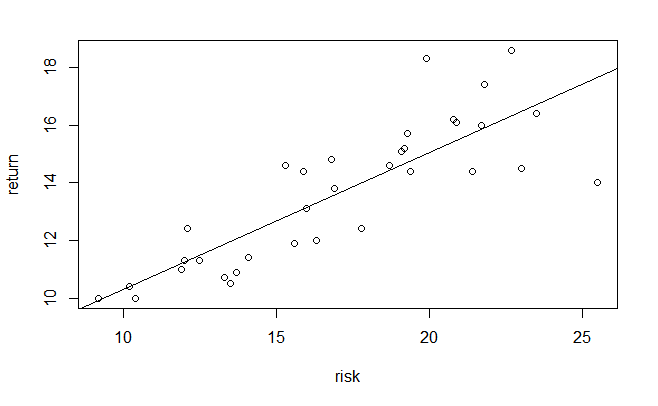

`r`r fitted(REGMODEL1)

```
        1         2         3         4         5         6
12.801007  9.906471 11.946882 13.275521 12.943361 11.282562
        7         8         9        10        11        12
13.512779 14.699064 12.041785 15.695544 13.085716 11.187659
       13        14        15        16        17        18
14.651613 14.414355 16.692024 16.454766 15.837898 14.604161
       19        20        21        22        23        24
12.231590 17.641052 15.885349 11.472368 10.475888 15.410835
       25        26        27        28        29        30
16.312412 14.983772 13.987293 10.380985 13.133167 11.851979
       31        32        33        34
14.746515 15.458287 11.235110 13.560230
```

# DJIA & S&P 500

`r`r djia_sp500_data <- read.csv(:/Users/prp12.000/GitHub-Repos/RStudio/datasets/djia_sp500_data.csv) attach(djia_sp500_data) names(djia_sp500_data)

```
[1] \date\  \djia\  \sp500\
```

`r`r ####################### plot(djia, sp500) REG_MODEL <- lm(sp500~djia) summary(REG_MODEL)

```
Call:
lm(formula = sp500 ~ djia)

Residuals:
    Min      1Q  Median      3Q     Max
-16.415  -6.378  -1.154   6.133  18.140

Coefficients:
              Estimate Std. Error t value       Pr(>|t|)
(Intercept) -669.02124  130.73358  -5.117       0.000198 ***
djia           0.15727    0.01015  15.488 0.000000000929 ***
---
Signif. codes:  0 â€˜***â€™ 0.001 â€˜**â€™ 0.01 â€˜*â€™ 0.05 â€˜.â€™ 0.1 â€˜ â€™ 1

Residual standard error: 9.608 on 13 degrees of freedom
Multiple R-squared:  0.9486,    Adjusted R-squared:  0.9446
F-statistic: 239.9 on 1 and 13 DF,  p-value: 0.0000000009292
```

`r`r abline(REG_MODEL)

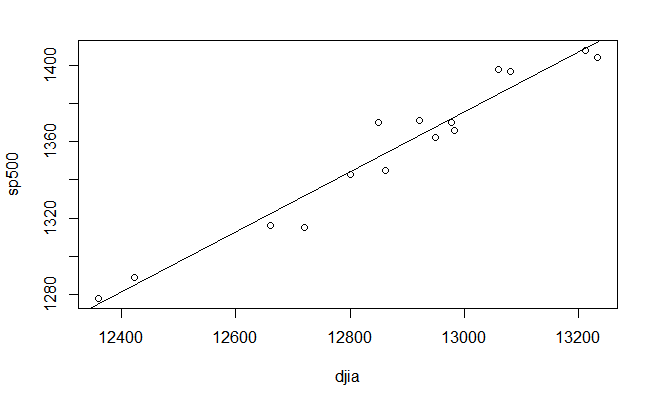

`r`r anova(REG_MODEL)

```
Analysis of Variance Table

Response: sp500
          Df  Sum Sq Mean Sq F value          Pr(>F)
djia       1 22145.6 22145.6  239.89 0.0000000009292 ***
Residuals 13  1200.1    92.3
---
Signif. codes:  0 â€˜***â€™ 0.001 â€˜**â€™ 0.01 â€˜*â€™ 0.05 â€˜.â€™ 0.1 â€˜ â€™ 1
```

`r`r cor(djia, sp500)

```
[1] 0.9739581
```

# Advertising Data

`r`r advertising_data <- read.csv(:/Users/prp12.000/GitHub-Repos/RStudio/datasets/advertising_data.csv) attach(advertising_data) dim(advertising_data)

```
[1] 200   4
```

`r`r names(advertising_data)

```
[1] \sales\     \TV\        \radio\     \newspaper\
```

`r`r summary(advertising_data)

```
     sales             TV             radio          newspaper
 Min.   : 1.60   Min.   :  0.70   Min.   : 0.000   Min.   :  0.30
 1st Qu.:10.38   1st Qu.: 74.38   1st Qu.: 9.975   1st Qu.: 12.75
 Median :12.90   Median :149.75   Median :22.900   Median : 25.75
 Mean   :14.02   Mean   :147.04   Mean   :23.264   Mean   : 30.55
 3rd Qu.:17.40   3rd Qu.:218.82   3rd Qu.:36.525   3rd Qu.: 45.10
 Max.   :27.00   Max.   :296.40   Max.   :49.600   Max.   :114.00
```

`r`r ############################# REG1 <- lm(sales~TV) summary(REG1)

```
Call:
lm(formula = sales ~ TV)

Residuals:
    Min      1Q  Median      3Q     Max
-8.3860 -1.9545 -0.1913  2.0671  7.2124

Coefficients:
            Estimate Std. Error t value            Pr(>|t|)
(Intercept) 7.032594   0.457843   15.36 <0.0000000000000002 ***
TV          0.047537   0.002691   17.67 <0.0000000000000002 ***
---
Signif. codes:  0 â€˜***â€™ 0.001 â€˜**â€™ 0.01 â€˜*â€™ 0.05 â€˜.â€™ 0.1 â€˜ â€™ 1

Residual standard error: 3.259 on 198 degrees of freedom
Multiple R-squared:  0.6119,    Adjusted R-squared:  0.6099
F-statistic: 312.1 on 1 and 198 DF,  p-value: < 0.00000000000000022
```

`r`r anova(REG1)

```
Analysis of Variance Table

Response: sales
           Df Sum Sq Mean Sq F value                Pr(>F)
TV          1 3314.6  3314.6  312.14 < 0.00000000000000022 ***
Residuals 198 2102.5    10.6
---
Signif. codes:  0 â€˜***â€™ 0.001 â€˜**â€™ 0.01 â€˜*â€™ 0.05 â€˜.â€™ 0.1 â€˜ â€™ 1
```

`r`r ############################# REG2 <- lm(sales~radio) summary(REG2)

```
Call:
lm(formula = sales ~ radio)

Residuals:
     Min       1Q   Median       3Q      Max
-15.7305  -2.1324   0.7707   2.7775   8.1810

Coefficients:
            Estimate Std. Error t value            Pr(>|t|)
(Intercept)  9.31164    0.56290  16.542 <0.0000000000000002 ***
radio        0.20250    0.02041   9.921 <0.0000000000000002 ***
---
Signif. codes:  0 â€˜***â€™ 0.001 â€˜**â€™ 0.01 â€˜*â€™ 0.05 â€˜.â€™ 0.1 â€˜ â€™ 1

Residual standard error: 4.275 on 198 degrees of freedom
Multiple R-squared:  0.332, Adjusted R-squared:  0.3287
F-statistic: 98.42 on 1 and 198 DF,  p-value: < 0.00000000000000022
```

`r`r anova(REG2)

```
Analysis of Variance Table

Response: sales
           Df Sum Sq Mean Sq F value                Pr(>F)
radio       1 1798.7 1798.67  98.422 < 0.00000000000000022 ***
Residuals 198 3618.5   18.28
---
Signif. codes:  0 â€˜***â€™ 0.001 â€˜**â€™ 0.01 â€˜*â€™ 0.05 â€˜.â€™ 0.1 â€˜ â€™ 1
```

`r`r ############################# REG3 <- lm(sales~newspaper) summary(REG3)

```
Call:
lm(formula = sales ~ newspaper)

Residuals:
     Min       1Q   Median       3Q      Max
-11.2272  -3.3873  -0.8392   3.5059  12.7751

Coefficients:
            Estimate Std. Error t value             Pr(>|t|)
(Intercept) 12.35141    0.62142   19.88 < 0.0000000000000002 ***
newspaper    0.05469    0.01658    3.30              0.00115 **
---
Signif. codes:  0 â€˜***â€™ 0.001 â€˜**â€™ 0.01 â€˜*â€™ 0.05 â€˜.â€™ 0.1 â€˜ â€™ 1

Residual standard error: 5.092 on 198 degrees of freedom
Multiple R-squared:  0.05212,   Adjusted R-squared:  0.04733
F-statistic: 10.89 on 1 and 198 DF,  p-value: 0.001148
```

`r`r anova(REG3)

```
Analysis of Variance Table

Response: sales
           Df Sum Sq Mean Sq F value   Pr(>F)
newspaper   1  282.3 282.344  10.887 0.001148 **
Residuals 198 5134.8  25.933
---
Signif. codes:  0 â€˜***â€™ 0.001 â€˜**â€™ 0.01 â€˜*â€™ 0.05 â€˜.â€™ 0.1 â€˜ â€™ 1
```

`r`r ################################# REG4 <- lm(sales~TV+radio+newspaper) summary(REG4)

```
Call:
lm(formula = sales ~ TV + radio + newspaper)

Residuals:
    Min      1Q  Median      3Q     Max
-8.8277 -0.8908  0.2418  1.1893  2.8292

Coefficients:
             Estimate Std. Error t value            Pr(>|t|)
(Intercept)  2.938889   0.311908   9.422 <0.0000000000000002 ***
TV           0.045765   0.001395  32.809 <0.0000000000000002 ***
radio        0.188530   0.008611  21.893 <0.0000000000000002 ***
newspaper   -0.001037   0.005871  -0.177                0.86
---
Signif. codes:  0 â€˜***â€™ 0.001 â€˜**â€™ 0.01 â€˜*â€™ 0.05 â€˜.â€™ 0.1 â€˜ â€™ 1

Residual standard error: 1.686 on 196 degrees of freedom
Multiple R-squared:  0.8972,    Adjusted R-squared:  0.8956
F-statistic: 570.3 on 3 and 196 DF,  p-value: < 0.00000000000000022
```

`r`r anova(REG4)

```
Analysis of Variance Table

Response: sales
           Df Sum Sq Mean Sq   F value              Pr(>F)
TV          1 3314.6  3314.6 1166.7308 <0.0000000000000002 ***
radio       1 1545.6  1545.6  544.0501 <0.0000000000000002 ***
newspaper   1    0.1     0.1    0.0312              0.8599
Residuals 196  556.8     2.8
---
Signif. codes:  0 â€˜***â€™ 0.001 â€˜**â€™ 0.01 â€˜*â€™ 0.05 â€˜.â€™ 0.1 â€˜ â€™ 1
```

`r`r ################################# cor(advertising_data)

```
              sales         TV      radio  newspaper
sales     1.0000000 0.78222442 0.57622257 0.22829903
TV        0.7822244 1.00000000 0.05480866 0.05664787
radio     0.5762226 0.05480866 1.00000000 0.35410375
newspaper 0.2282990 0.05664787 0.35410375 1.00000000
```

# Toyota Carolla

`r`r toyota_corolla_data <- read.csv(:/Users/prp12.000/GitHub-Repos/RStudio/datasets/toyota_corolla_data.csv) attach(toyota_corolla_data)

`r`r library(psych) library(Metrics)

`r`r options(scipen = 999) # <– EDA –> library(psych) describe(toyota_corolla_data) r # <– CREATING TRAINING & TEST SET –> set.seed(1234) USABLE_DATA <- toyota_corolla_data[c(-1, -2, -6, -8,-11, -15)] RANDOMIZED_DATA <- USABLE_DATA[order(runif(1436)), ] RANDOMIZED_DATA

|  | vars | n | mean | sd | median | trimmed | mad | min | max | range | skew | kurtosis | se |
| --- | --- | --- | --- | --- | --- | --- | --- | --- | --- | --- | --- | --- | --- |
| id | 1 | 1436 | 721.56 | 416.48 | 721.5 | 721.54 | 533.74 | 1 | 1442 | 1441 | 0.00 | -1.20 | 10.99 |
| model* | 2 | 1436 | 168.06 | 84.12 | 165.0 | 164.04 | 65.23 | 1 | 372 | 371 | 0.40 | -0.13 | 2.22 |
| price | 3 | 1436 | 10730.82 | 3626.96 | 9900.0 | 10160.59 | 2446.29 | 4350 | 32500 | 28150 | 1.70 | 3.71 | 95.71 |
| Age_08_04 | 4 | 1436 | 55.95 | 18.60 | 61.0 | 57.93 | 17.79 | 1 | 80 | 79 | -0.82 | -0.08 | 0.49 |
| Mfg_Month | 5 | 1436 | 5.55 | 3.35 | 5.0 | 5.38 | 4.45 | 1 | 12 | 11 | 0.29 | -1.06 | 0.09 |
| Mfg_Year | 6 | 1436 | 1999.63 | 1.54 | 1999.0 | 1999.43 | 1.48 | 1998 | 2004 | 6 | 0.91 | 0.06 | 0.04 |
| km | 7 | 1436 | 68533.26 | 37506.45 | 63389.5 | 65249.58 | 32517.12 | 1 | 243000 | 242999 | 1.01 | 1.67 | 989.76 |
| Fuel_Type* | 8 | 1436 | 2.87 | 0.37 | 3.0 | 2.97 | 0.00 | 1 | 3 | 2 | -2.84 | 7.80 | 0.01 |
| HP | 9 | 1436 | 101.50 | 14.98 | 110.0 | 102.96 | 0.00 | 69 | 192 | 123 | 0.95 | 8.79 | 0.40 |
| Met_Color | 10 | 1436 | 0.67 | 0.47 | 1.0 | 0.72 | 0.00 | 0 | 1 | 1 | -0.75 | -1.45 | 0.01 |

[output cut: 29 more lines]

`r`r TRAINING_SET <- RANDOMIZED_DATA[1:1000,] TRAINING_SET

|  | price | Age_08_04 | Mfg_Month | km | HP | Met_Color | Automatic | CC | Doors | Gears | Quarterly_Tax | Weight | Mfr_Guarantee | BOVAG_Guarantee | Guarantee_Period | ABS | Airbag_1 | Airbag_2 | Airco | Automatic_airco | Boardcomputer | CD_Player | Central_Lock | Powered_Windows | Power_Steering | Radio | Mistlamps | Sport_Model | Backseat_Divider | … |
| --- | --- | --- | --- | --- | --- | --- | --- | --- | --- | --- | --- | --- | --- | --- | --- | --- | --- | --- | --- | --- | --- | --- | --- | --- | --- | --- | --- | --- | --- | --- |
| 783 | 8950 | 59 | 10 | 76162 | 110 | 1 | 0 | 1600 | 5 | 5 | 85 | 1075 | 0 | 1 | 3 | 1 | 1 | 1 | 1 | 0 | 0 | 0 | 1 | 1 | 1 | 0 | 1 | 0 | 1 | … |
| 473 | 9950 | 52 | 5 | 65170 | 97 | 1 | 0 | 1400 | 3 | 5 | 69 | 1025 | 1 | 1 | 3 | 1 | 1 | 1 | 1 | 0 | 1 | 0 | 0 | 0 | 1 | 1 | 0 | 0 | 1 | … |
| 746 | 8450 | 68 | 1 | 81965 | 86 | 1 | 0 | 1300 | 5 | 5 | 69 | 1035 | 1 | 1 | 3 | 1 | 1 | 1 | 0 | 0 | 0 | 0 | 0 | 0 | 1 | 0 | 0 | 0 | 1 | … |
| 996 | 9950 | 68 | 1 | 42750 | 110 | 1 | 0 | 1600 | 3 | 5 | 69 | 1050 | 0 | 1 | 3 | 1 | 1 | 1 | 0 | 0 | 0 | 0 | 0 | 0 | 1 | 0 | 0 | 0 | 1 | … |
| 1115 | 6900 | 76 | 5 | 115345 | 110 | 1 | 0 | 1600 | 5 | 5 | 85 | 1070 | 0 | 1 | 3 | 0 | 1 | 0 | 0 | 0 | 0 | 0 | 1 | 1 | 1 | 0 | 0 | 0 | 1 | … |
| 383 | 8900 | 45 | 12 | 174000 | 69 | 1 | 0 | 1900 | 5 | 5 | 185 | 1095 | 0 | 0 | 6 | 1 | 1 | 0 | 1 | 0 | 0 | 0 | 1 | 0 | 1 | 0 | 0 | 0 | 0 | … |
| 361 | 12950 | 39 | 6 | 24444 | 110 | 1 | 0 | 1600 | 3 | 5 | 69 | 1040 | 1 | 1 | 3 | 1 | 1 | 1 | 0 | 0 | 1 | 0 | 0 | 0 | 1 | 1 | 0 | 0 | 1 | … |
| 973 | 9500 | 66 | 3 | 47237 | 110 | 0 | 0 | 1600 | 3 | 5 | 69 | 1050 | 0 | 1 | 12 | 0 | 1 | 0 | 0 | 0 | 0 | 0 | 1 | 1 | 1 | 0 | 0 | 0 | 0 | … |
| 258 | 11750 | 44 | 1 | 52084 | 97 | 1 | 0 | 1400 | 3 | 5 | 69 | 1025 | 1 | 1 | 3 | 1 | 1 | 1 | 1 | 0 | 1 | 0 | 0 | 0 | 1 | 0 | 0 | 0 | 1 | … |
| 1033 | 10950 | 60 | 9 | 28500 | 110 | 0 | 0 | 1600 | 5 | 5 | 85 | 1075 | 0 | 1 | 3 | 1 | 1 | 1 | 1 | 0 | 0 | 0 | 1 | 1 | 1 | 0 | 1 | 0 | 1 | … |

[output cut: 990 more lines]

`r`r TEST_SET <- RANDOMIZED_DATA[1001:1436,] TEST_SET

[output not shown]

`r`r REG_MODEL <- lm(price~., data = TRAINING_SET) summary(REG_MODEL)

```
Call:
lm(formula = price ~ ., data = TRAINING_SET)

Residuals:
    Min      1Q  Median      3Q     Max
-6749.3  -613.1   -50.5   605.9  5560.3

Coefficients:
                      Estimate   Std. Error t value
(Intercept)        5003.151475  1644.050892   3.043
Age_08_04          -120.910243     4.146336 -29.161
Mfg_Month           -96.259271    10.776425  -8.932
km                   -0.017241     0.001322 -13.043
HP                   27.039161     3.165923   8.541
Met_Color            -9.601620    80.047511  -0.120
Automatic           399.174270   163.958118   2.435
CC                   -1.190026     0.322278  -3.693
Doors                98.485738    41.428705   2.377
Gears               280.540631   230.398170   1.218
Quarterly_Tax        11.947845     1.572136   7.600
Weight                9.060812     1.179034   7.685
Mfr_Guarantee       224.390816    77.711966   2.887
BOVAG_Guarantee     454.960411   133.212329   3.415
Guarantee_Period     73.113564    14.679569   4.981
ABS                -177.352456   131.621459  -1.347
Airbag_1            293.212256   280.406753   1.046
Airbag_2           -188.924898   135.411995  -1.395
Airco               225.188551    95.295204   2.363
Automatic_airco    2524.256194   207.090560  12.189
Boardcomputer      -258.657255   124.714447  -2.074
CD_Player           188.281172   104.465766   1.802
Central_Lock        -44.981671   156.637188  -0.287
Powered_Windows     313.563930   155.945974   2.011
Power_Steering     -304.448841   302.239431  -1.007
Radio             -1295.383521  1137.587736  -1.139
Mistlamps            15.012898   116.951901   0.128
Sport_Model         377.820763    92.812480   4.071
Backseat_Divider   -214.780430   128.984398  -1.665
Metallic_Rim        181.287762    99.704061   1.818
Radio_cassette     1121.037198  1140.581312   0.983
```

[output cut: 27 more lines]

```
Power_Steering                0.314038
Radio                         0.255106
Mistlamps                     0.897884
Sport_Model         0.0000506796207406 ***
Backseat_Divider              0.096204 .
Metallic_Rim                  0.069334 .
Radio_cassette                0.325920
Parking_Assistant             0.157397
Tow_Bar                       0.010726 *
---
Signif. codes:  0 â€˜***â€™ 0.001 â€˜**â€™ 0.01 â€˜*â€™ 0.05 â€˜.â€™ 0.1 â€˜ â€™ 1

Residual standard error: 1102 on 967 degrees of freedom
Multiple R-squared:  0.9121,    Adjusted R-squared:  0.9092
F-statistic: 313.4 on 32 and 967 DF,  p-value: < 0.00000000000000022
```

`r`r # <– COMPUTING RMSE OF TRAINING SET –> FITTED_VALUES <- fitted(REG_MODEL) library(Metrics) rmse(TRAINING_SET$price, FITTED_VALUES)

```
[1] 1083.292
```

`r`r # <– RMSE OF TEST SET –> PREDICTIONS <- predict(REG_MODEL, TEST_SET) PREDICTIONS

```
     1015       244      1035       976       391       757
11217.264 13768.522 10158.639  8518.411  9930.316  9748.249
       11       297       995      1028      1319      1354
22194.722 14481.358  8759.203 10767.047  8384.070 10986.716
      289       598      1075      1298      1356       218
12748.538 10992.231  7011.136  6850.221  7434.772 11160.507
      789       488      1169       795        66      1323
 8301.693 11370.460  6076.648 10230.702 17660.418  8375.667
     1343      1044       711       951       972       173
 8917.075  9809.423  8767.461  9167.801  9307.240 18985.148
      354      1426       667      1122       837       703
13290.316  8655.189  9115.283  7065.220  9796.922  8150.690
      111      1385       850        53      1373      1132
27006.292  7883.741 10020.425 19289.865  7857.830  7430.956
      479      1111      1249       370      1097       670
10779.733  7556.673  7931.862 13511.930  6704.818  9210.835
     1203      1119       358       206       393       198
 7902.994  7864.162 14070.477 12395.041  9847.314 13576.366
      331       439      1278       285      1099       700
13044.915  9703.421  8689.501 12389.141  7110.905  8245.958
      392      1324       147      1210       100       190
 9729.815  8789.846 17764.474  7150.814 17042.580 11120.901
      352       752       121       849       443       507
12678.269 10019.966 16456.588 10187.359 10919.497 10679.948
      892       539       270      1422       267       545
 9545.526 11363.370 12218.464  8279.606 13238.160 11131.948
     1344       237       977       455        58      1383
 8712.505 14942.858  9480.807 11491.526 15288.607  8134.426
     1417       403       171       927       296       214
 8223.502  8657.263 18360.978 10876.023 11854.294 11842.464
      407       272       176       377        36      1005
10131.632 12663.265 21830.037 13903.716 15189.309 10563.678
      487      1063      1322      1250       492       489
11456.311  5432.982  7971.599  7292.749 10293.154 11122.562
     1129        50       875       997       944       204
 7524.451 20819.956  9257.755 10691.977  8881.173 12125.117
     1400       360       310       974       859       247
 8230.092 13852.951 13404.060  9006.888  9985.326 12687.294
     1218       418       404       452       411       909
 8355.545 10841.937  9968.555 11120.305 10107.430  9695.881
```

[output cut: 91 more lines]

```
11797.277  9337.206  8991.034 12008.668  9512.427  9746.520
      366       344      1024       549       245       899
12536.787 13137.723  9559.975 10783.242 12949.536  8896.733
      149       302       868       918       199       142
19875.631 12585.337  9288.100 10904.446 10394.205 19683.007
     1393       389       988       210       726       730
 7982.735  9387.447  8300.255 14544.334  8220.542  8781.757
      993       985       739      1010       156       445
 9058.656 10648.778  8731.457  9931.035 17083.072 11404.179
      240       562       932      1114       308        39
13889.226 10291.113  9713.510  7152.084 13473.925 15336.464
      192      1376       536       123      1082      1416
 9338.895  7598.992 11971.573 16525.558  7784.175  8264.070
      453       158       355       971
10594.039 17298.996 12610.492  8944.826
```

`r`r rmse(TEST_SET$price, PREDICTIONS)

```
[1] 1417.062
```

[output not shown]

[output cut: 426 more lines]

# Airfares Data

`r`r airfares_data <- read.csv(:/Users/prp12.000/GitHub-Repos/RStudio/datasets/airfares_data.csv) ## <– EXPLORATORY DATA ANALYSIS –> ## attach(airfares_data)

`r`r dim(airfares_data)

```
[1] 638  18
```

`r`r str(airfares_data)

```
'data.frame':   638 obs. of  18 variables:
 $ S_CODE  : Factor w/ 8 levels \*\,\DCA\,\EWR\,..: 1 1 1 8 7 1 1 1 1 1 ...
 $ S_CITY  : Factor w/ 51 levels \Albuquerque         NM\,..: 14 3 7 9 9 11 14 18 23 25 ...
 $ E_CODE  : Factor w/ 8 levels \*\,\DCA\,\EWR\,..: 1 1 1 1 1 1 1 1 1 1 ...
 $ E_CITY  : Factor w/ 68 levels \Amarillo            TX\,..: 1 2 2 2 2 2 2 2 2 2 ...
 $ COUPON  : num  1 1.06 1.06 1.06 1.06 1.01 1.28 1.15 1.33 1.6 ...
 $ NEW     : int  3 3 3 3 3 3 3 3 3 2 ...
 $ VACATION: Factor w/ 2 levels \No\,\Yes\: 1 1 1 1 1 1 1 2 1 1 ...
 $ SW      : Factor w/ 2 levels \No\,\Yes\: 2 1 1 2 2 2 1 2 2 2 ...
 $ HI      : num  5292 5419 9185 2657 2657 ...
 $ S_INCOME: int  28637 26993 30124 29260 29260 26046 28637 26752 27211 25450 ...
 $ E_INCOME: int  21112 29838 29838 29838 29838 29838 29838 29838 29838 29838 ...
 $ S_POP   : int  3036732 3532657 5787293 7830332 7830332 2230955 3036732 1440377 3770125 1694803 ...
 $ E_POP   : int  205711 7145897 7145897 7145897 7145897 7145897 7145897 7145897 7145897 7145897 ...
 $ SLOT    : Factor w/ 2 levels \Controlled\,\Free\: 2 2 2 1 2 2 2 2 2 2 ...
 $ GATE    : Factor w/ 2 levels \Constrained\,..: 2 2 2 2 2 2 2 2 2 2 ...
 $ DISTANCE: int  312 576 364 612 612 309 1220 921 1249 964 ...
 $ PAX     : int  7864 8820 6452 25144 25144 13386 4625 5512 7811 4657 ...
 $ FARE    : num  64.1 174.5 207.8 85.5 85.5 ...
```

`r`r library(psych) describe(airfares_data) r CORRELATION_DATA <- data.frame(COUPON, NEW, HI, S_INCOME, E_INCOME, S_POP, E_POP, DISTANCE, PAX, FARE) COR_MATRIX <- cor(CORRELATION_DATA) COR_MATRIX

```
              COUPON         NEW          HI    S_INCOME    E_INCOME
COUPON    1.00000000  0.02022307 -0.34725189 -0.08840265  0.04688920
NEW       0.02022307  1.00000000  0.05414692  0.02659673  0.11337664
HI       -0.34725189  0.05414692  1.00000000 -0.02738225  0.08239257
S_INCOME -0.08840265  0.02659673 -0.02738225  1.00000000 -0.13886420
E_INCOME  0.04688920  0.11337664  0.08239257 -0.13886420  1.00000000
S_POP    -0.10776336 -0.01667212 -0.17249547  0.51718718 -0.14405857
E_POP     0.09496994  0.05856818 -0.06245621 -0.27228027  0.45841806
DISTANCE  0.74680521  0.08096520 -0.31237445  0.02815334  0.17653074
PAX      -0.33697358  0.01049527 -0.16896110  0.13819710  0.25996105
FARE      0.49653696  0.09172969  0.02519501  0.20913485  0.32609229
               S_POP       E_POP    DISTANCE         PAX        FARE
COUPON   -0.10776336  0.09496994  0.74680521 -0.33697358  0.49653696
NEW      -0.01667212  0.05856818  0.08096520  0.01049527  0.09172969
HI       -0.17249547 -0.06245621 -0.31237445 -0.16896110  0.02519501
S_INCOME  0.51718718 -0.27228027  0.02815334  0.13819710  0.20913485
E_INCOME -0.14405857  0.45841806  0.17653074  0.25996105  0.32609229
S_POP     1.00000000 -0.28014283  0.01843667  0.28461056  0.14509708
E_POP    -0.28014283  1.00000000  0.11563970  0.31469750  0.28504299
DISTANCE  0.01843667  0.11563970  1.00000000 -0.10248160  0.67001599
PAX       0.28461056  0.31469750 -0.10248160  1.00000000 -0.09070541
FARE      0.14509708  0.28504299  0.67001599 -0.09070541  1.00000000
```

`r`r CORRELATION_MATRIX <- round(COR_MATRIX, 2) CORRELATION_MATRIX

```
         COUPON   NEW    HI S_INCOME E_INCOME S_POP E_POP DISTANCE
COUPON     1.00  0.02 -0.35    -0.09     0.05 -0.11  0.09     0.75
NEW        0.02  1.00  0.05     0.03     0.11 -0.02  0.06     0.08
HI        -0.35  0.05  1.00    -0.03     0.08 -0.17 -0.06    -0.31
S_INCOME  -0.09  0.03 -0.03     1.00    -0.14  0.52 -0.27     0.03
E_INCOME   0.05  0.11  0.08    -0.14     1.00 -0.14  0.46     0.18
S_POP     -0.11 -0.02 -0.17     0.52    -0.14  1.00 -0.28     0.02
E_POP      0.09  0.06 -0.06    -0.27     0.46 -0.28  1.00     0.12
DISTANCE   0.75  0.08 -0.31     0.03     0.18  0.02  0.12     1.00
PAX       -0.34  0.01 -0.17     0.14     0.26  0.28  0.31    -0.10
FARE       0.50  0.09  0.03     0.21     0.33  0.15  0.29     0.67
           PAX  FARE
COUPON   -0.34  0.50
NEW       0.01  0.09
HI       -0.17  0.03
S_INCOME  0.14  0.21
E_INCOME  0.26  0.33
S_POP     0.28  0.15
E_POP     0.31  0.29
DISTANCE -0.10  0.67
PAX       1.00 -0.09
FARE     -0.09  1.00
```

`r`r ## <– FULL REGRESSION MODEL –> ## options(scipen = 999) FULL_REG_MODEL <- lm(FARE ~ COUPON + NEW + VACATION + SW + HI + S_INCOME + E_INCOME + S_POP + E_POP + SLOT + GATE + DISTANCE + PAX) summary(FULL_REG_MODEL)

```
Call:
lm(formula = FARE ~ COUPON + NEW + VACATION + SW + HI + S_INCOME +
    E_INCOME + S_POP + E_POP + SLOT + GATE + DISTANCE + PAX)

Residuals:
     Min       1Q   Median       3Q      Max
-106.329  -22.707   -2.329   21.135  128.694

Coefficients:
                  Estimate     Std. Error t value
(Intercept)  12.6993915337  27.3794269858   0.464
COUPON        3.7548909844  12.1940741390   0.308
NEW          -2.3955314942   1.8754235204  -1.277
VACATIONYes -35.6444410042   3.6170501865  -9.855
SWYes       -40.9695969113   3.7437292880 -10.944
HI            0.0084257918   0.0009900663   8.510
S_INCOME      0.0012066780   0.0005171071   2.334
E_INCOME      0.0013742726   0.0003749187   3.666
S_POP         0.0000034009   0.0000006523   5.213
E_POP         0.0000043631   0.0000007547   5.781
SLOTFree    -16.2447672500   3.8468795785  -4.223
GATEFree    -20.5792305291   4.0015842717  -5.143
DISTANCE      0.0749842548   0.0035795487  20.948
PAX          -0.0008709425   0.0001459072  -5.969
                        Pr(>|t|)
(Intercept)             0.642932
COUPON                  0.758240
NEW                     0.201961
VACATIONYes < 0.0000000000000002 ***
SWYes       < 0.0000000000000002 ***
HI          < 0.0000000000000002 ***
S_INCOME                0.019938 *
E_INCOME                0.000268 ***
S_POP               0.0000002525 ***
E_POP               0.0000000117 ***
SLOTFree            0.0000277170 ***
GATEFree            0.0000003629 ***
DISTANCE    < 0.0000000000000002 ***
PAX                 0.0000000040 ***
---
Signif. codes:  0 â€˜***â€™ 0.001 â€˜**â€™ 0.01 â€˜*â€™ 0.05 â€˜.â€™ 0.1 â€˜ â€™ 1

Residual standard error: 35.47 on 624 degrees of freedom
Multiple R-squared:  0.7868,    Adjusted R-squared:  0.7823
F-statistic: 177.1 on 13 and 624 DF,  p-value: < 0.00000000000000022
```

`r`r ## <– REG_SUBSETS –> ## library(leaps)

`r`r REG_SUBSETS <- regsubsets(FARE ~ COUPON + NEW + VACATION + SW + HI + S_INCOME + E_INCOME + S_POP + E_POP + SLOT + GATE + DISTANCE + PAX, data = airfares_data, nvmax = 13 ) summary(REG_SUBSETS)

```
Subset selection object
Call: regsubsets.formula(FARE ~ COUPON + NEW + VACATION + SW + HI +
    S_INCOME + E_INCOME + S_POP + E_POP + SLOT + GATE + DISTANCE +
    PAX, data = airfares_data, nvmax = 13)
13 Variables  (and intercept)
            Forced in Forced out
COUPON          FALSE      FALSE
NEW             FALSE      FALSE
VACATIONYes     FALSE      FALSE
SWYes           FALSE      FALSE
HI              FALSE      FALSE
S_INCOME        FALSE      FALSE
E_INCOME        FALSE      FALSE
S_POP           FALSE      FALSE
E_POP           FALSE      FALSE
SLOTFree        FALSE      FALSE
GATEFree        FALSE      FALSE
DISTANCE        FALSE      FALSE
PAX             FALSE      FALSE
1 subsets of each size up to 13
Selection Algorithm: exhaustive
          COUPON NEW VACATIONYes SWYes HI  S_INCOME E_INCOME S_POP
1  ( 1 )  \ \    \ \ \ \         \ \   \ \ \ \      \ \      \ \
2  ( 1 )  \ \    \ \ \ \         \*\   \ \ \ \      \ \      \ \
3  ( 1 )  \ \    \ \ \*\         \*\   \ \ \ \      \ \      \ \
4  ( 1 )  \ \    \ \ \*\         \*\   \*\ \ \      \ \      \ \
5  ( 1 )  \ \    \ \ \*\         \*\   \*\ \ \      \ \      \ \
6  ( 1 )  \ \    \ \ \*\         \*\   \*\ \ \      \ \      \ \
7  ( 1 )  \ \    \ \ \*\         \*\   \*\ \ \      \ \      \*\
8  ( 1 )  \ \    \ \ \*\         \*\   \*\ \ \      \ \      \*\
9  ( 1 )  \ \    \ \ \*\         \*\   \*\ \ \      \ \      \*\
10  ( 1 ) \ \    \ \ \*\         \*\   \*\ \ \      \*\      \*\
11  ( 1 ) \ \    \ \ \*\         \*\   \*\ \*\      \*\      \*\
12  ( 1 ) \ \    \*\ \*\         \*\   \*\ \*\      \*\      \*\
13  ( 1 ) \*\    \*\ \*\         \*\   \*\ \*\      \*\      \*\
          E_POP SLOTFree GATEFree DISTANCE PAX
1  ( 1 )  \ \   \ \      \ \      \*\      \ \
2  ( 1 )  \ \   \ \      \ \      \*\      \ \
3  ( 1 )  \ \   \ \      \ \      \*\      \ \
4  ( 1 )  \ \   \ \      \ \      \*\      \ \
5  ( 1 )  \ \   \*\      \ \      \*\      \ \
6  ( 1 )  \ \   \*\      \*\      \*\      \ \
7  ( 1 )  \*\   \ \      \ \      \*\      \*\
8  ( 1 )  \*\   \ \      \*\      \*\      \*\
9  ( 1 )  \*\   \*\      \*\      \*\      \*\
10  ( 1 ) \*\   \*\      \*\      \*\      \*\
11  ( 1 ) \*\   \*\      \*\      \*\      \*\
12  ( 1 ) \*\   \*\      \*\      \*\      \*\
13  ( 1 ) \*\   \*\      \*\      \*\      \*\
```

`r`r REG_SUMMARY <- summary(REG_SUBSETS) REG_SUMMARY$adjr2

```
 [1] 0.4480550 0.6031119 0.7064340 0.7318363 0.7437300 0.7602224
 [7] 0.7640663 0.7690798 0.7775265 0.7809381 0.7824096 0.7826435
[13] 0.7823282
```

`r`r ## <– Best Model –> ## BEST_4_VARIABLE_MODEL <- lm(FARE ~ VACATION + SW + HI + DISTANCE) summary(BEST_4_VARIABLE_MODEL)

```
Call:
lm(formula = FARE ~ VACATION + SW + HI + DISTANCE)

Residuals:
     Min       1Q   Median       3Q      Max
-101.533  -24.679   -2.249   25.694  121.924

Coefficients:
               Estimate  Std. Error t value             Pr(>|t|)
(Intercept)  83.6667884   6.3216258  13.235 < 0.0000000000000002 ***
VACATIONYes -52.1011141   3.5729193 -14.582 < 0.0000000000000002 ***
SWYes       -61.0621080   3.5202010 -17.346 < 0.0000000000000002 ***
HI            0.0075586   0.0009673   7.814   0.0000000000000232 ***
DISTANCE      0.0779823   0.0026404  29.535 < 0.0000000000000002 ***
---
Signif. codes:  0 â€˜***â€™ 0.001 â€˜**â€™ 0.01 â€˜*â€™ 0.05 â€˜.â€™ 0.1 â€˜ â€™ 1

Residual standard error: 39.37 on 633 degrees of freedom
Multiple R-squared:  0.7335,    Adjusted R-squared:  0.7318
F-statistic: 435.6 on 4 and 633 DF,  p-value: < 0.00000000000000022
```

[output not shown]

[output cut: 8 more lines]

# Occupational Prestige

`r`r occupational_prestige_data <- read.csv(:/Users/prp12.000/GitHub-Repos/RStudio/datasets/occupational_prestige_data.csv) ## <– Initialize Workspace –> ## attach(occupational_prestige_data)

`r`r describe(occupational_prestige_data) r min(prestige)

```
[1] 14.8
```

[output not shown]

`r`r max(prestige)

```
[1] 87.2
```

[output not shown]

`r`r ## <– MODEL_1 –> ## MODEL_1 <- lm(prestige ~ education + income + percentage_of_women + professional ) summary(MODEL_1)

```
Call:
lm(formula = prestige ~ education + income + percentage_of_women +
    professional)

Residuals:
     Min       1Q   Median       3Q      Max
-18.9275  -4.6033  -0.0015   4.8288  19.2510

Coefficients:
                      Estimate Std. Error t value     Pr(>|t|)
(Intercept)          3.6153596  4.4637541   0.810      0.41996
education            3.0185168  0.5178846   5.829 0.0000000731 ***
income               0.0011768  0.0002686   4.381 0.0000298877 ***
percentage_of_women -0.0009108  0.0291425  -0.031      0.97513
professionalyes      9.3160805  2.8801637   3.235      0.00167 **
---
Signif. codes:  0 â€˜***â€™ 0.001 â€˜**â€™ 0.01 â€˜*â€™ 0.05 â€˜.â€™ 0.1 â€˜ â€™ 1

Residual standard error: 7.493 on 97 degrees of freedom
Multiple R-squared:  0.8178,    Adjusted R-squared:  0.8103
F-statistic: 108.9 on 4 and 97 DF,  p-value: < 0.00000000000000022
```

`r`r ## <– PRESTIGE_DATA –> ## library(dplyr) PRESTIGE_DATA <- data.frame(select(occupational_prestige_data, prestige, education, income, percentage_of_women)) Z_PRESTIGE_DATA <- data.frame(scale(PRESTIGE_DATA)) describe(Z_PRESTIGE_DATA)

[output not shown]

`r`r ## <– MODEL_2 –> ## MODEL_2 <- lm(prestige ~ education + income + percentage_of_women, data = Z_PRESTIGE_DATA) summary(MODEL_2)

```
Call:
lm(formula = prestige ~ education + income + percentage_of_women,
    data = Z_PRESTIGE_DATA)

Residuals:
     Min       1Q   Median       3Q      Max
-1.15229 -0.30999 -0.00793  0.29984  1.01744

Coefficients:
                                   Estimate              Std. Error
(Intercept)         -0.00000000000000001396  0.04515775779186551736
education            0.66395512597124961562  0.06164379142481105078
income               0.32417565747255405739  0.06855406168027983194
percentage_of_women -0.01642103617685423955  0.05607036552368137305
                    t value             Pr(>|t|)
(Intercept)           0.000                 1.00
education            10.771 < 0.0000000000000002 ***
income                4.729           0.00000758 ***
percentage_of_women  -0.293                 0.77
---
Signif. codes:  0 â€˜***â€™ 0.001 â€˜**â€™ 0.01 â€˜*â€™ 0.05 â€˜.â€™ 0.1 â€˜ â€™ 1

Residual standard error: 0.4561 on 98 degrees of freedom
Multiple R-squared:  0.7982,    Adjusted R-squared:  0.792
F-statistic: 129.2 on 3 and 98 DF,  p-value: < 0.00000000000000022
```

`r`r STANDARDIZED_AND_UNSTANDARDIZED_DATA <- data.frame(Z_PRESTIGE_DATA, professional) STANDARDIZED_AND_UNSTANDARDIZED_DATA

[output not shown]

`r`r ## <– MODEL_3 –> ## MODEL_3 <- lm(prestige ~ education + income + percentage_of_women + professional, data = STANDARDIZED_AND_UNSTANDARDIZED_DATA) summary(MODEL_3)

```
Call:
lm(formula = prestige ~ education + income + percentage_of_women +
    professional, data = STANDARDIZED_AND_UNSTANDARDIZED_DATA)

Residuals:
     Min       1Q   Median       3Q      Max
-1.10015 -0.26757 -0.00009  0.28067  1.11895

Coefficients:
                     Estimate Std. Error t value     Pr(>|t|)
(Intercept)         -0.164571   0.066696  -2.467      0.01536 *
education            0.478704   0.082131   5.829 0.0000000731 ***
income               0.290435   0.066292   4.381 0.0000298877 ***
percentage_of_women -0.001679   0.053739  -0.031      0.97513
professionalyes      0.541491   0.167408   3.235      0.00167 **
---
Signif. codes:  0 â€˜***â€™ 0.001 â€˜**â€™ 0.01 â€˜*â€™ 0.05 â€˜.â€™ 0.1 â€˜ â€™ 1

Residual standard error: 0.4355 on 97 degrees of freedom
Multiple R-squared:  0.8178,    Adjusted R-squared:  0.8103
F-statistic: 108.9 on 4 and 97 DF,  p-value: < 0.00000000000000022
```

[output not shown]

[output cut: 92 more lines]

# Murder Data

`r`r psych(murder_data)

```
Error in psych(murder_data) : unused argument (murder_data)
```

# Investment GDP Data

## <– MODEL IN TRILLIONS –>

REG_MODEL1 <- lm(gross_private_domestic_investment~gdp) summary(REG_MODEL1)

## <– MODEL IN BILLIONS –>

GPDI <- (gross_private_domestic_investment*1000) GPDI GDP <- (gdp*1000) GDP REG_MODEL2 <- lm(GPDI~GDP) summary(REG_MODEL2)

# Stock Volume Data

`r`r ## <– Initialize Workspace –> ## stock_volume_data <- read.csv(:/Users/prp12.000/GitHub-Repos/RStudio/datasets/stock_volume_data.csv) attach(stock_volume_data) options(scipen = 999)

## <– Model 1 –>

MODEL_1 <- lm(stock_volume ~ stock_price_1 + stock_price_2) summary(MODEL_1)

plot(stock_price_1, stock_price_2) cor(stock_price_1, stock_price_2)

# Affairs Data

`r`r affairs_data <- read.csv(:/Users/prp12.000/GitHub-Repos/RStudio/datasets/affairs_data.csv) attach(affairs_data) names(affairs_data) str(affairs_data) options(scipen = 999)

library(psych) describe(affairs_data) FREQUENCY_TABLE <- table(number_affairs) FREQUENCY_TABLE PROBABILITY_TABLE <- prop.table(FREQUENCY_TABLE) PROBABILITY_TABLE

LOGISTIC REGRESSION MODEL

FULL_MODEL <- glm(YNAFFAIRS~male+age+years_married+children+ religious+education+occupation+marriage_rating, data = affairs_data, family=binomial()) summary(FULL_MODEL)

REDUCED_MODEL <- glm(YNAFFAIRS~age+years_married+religious+marriage_rating, data = affairs_data, family=binomial()) summary(REDUCED_MODEL)

coef(REDUCED_MODEL) exp(coef(REDUCED_MODEL)) ####This tranforms regression coefficients into Odds###

LOGITS <- data.frame(predict(REDUCED_MODEL)) LOGITS

ODDS <- data.frame(exp(LOGITS)) ODDS

PROBABILITY <- data.frame(ODDS/(1 + ODDS)) PROBABILITY

min(PROBABILITY) max(PROBABILITY)

describe(PROBABILITY)

CONFUSION MATRIX

COMPARISON <- data.frame(ACTUAL_STATE, PREDICTED_STATE)

TABLE <- table(COMPARISON) TABLE

CONFUSION_MATRIX <- prop.table(TABLE) CONFUSION_MATRIX

LDA MODEL

library(DiscriMiner) LDA_DATASET <- data.frame(ACTUAL_STATE, age, years_married,religious, marriage_rating)

LDA_MODEL <- linDA((LDA_DATASET) [,2:5],ACTUAL_STATE) summary(LDA_MODEL)

LDA_MODEL$functions LDA_MODEL$scores LDA_MODEL$classification LDA_MODEL$confusion

LDA_TABLE <- LDA_MODEL$confusion LDA_CONFUSION_MATRIX <- prop.table(LDA_TABLE) LDA_CONFUSION_MATRIX

# Credit Default Data

`r`r credit_default_data <- read.csv(:/Users/prp12.000/GitHub-Repos/RStudio/datasets/credit_default_data.csv) library(psych) library(DiscriMiner) library(plyr) library(outliers) options(scipen = 999) ###################################################### dim(credit_default_data) names(credit_default_data) str(credit_default_data) attach(credit_default_data) describe(credit_default_data)

table(default) outlier(balance) outlier(income) ####################LOGIT MODEL############################ LOGIT_MODEL <- glm(default~student+balance+income, data = credit_default_data, family = binomial())

summary(LOGIT_MODEL) predict(LOGIT_MODEL) ODDS <- exp(predict(LOGIT_MODEL)) ODDS

PROB <- (ODDS)/(1 + ODDS) PROBABILITY <- data.frame(PROB*100) describe(PROBABILITY)

LDA MODEL

library(DiscriMiner) contrasts(as.factor(default))

LDA_MODEL <- linDA(credit_default_data[,3:5], credit_default_data[,2]) LDA_MODEL LDA_MODEL$scores LDA_MODEL$classification

COMPARISON <- data.frame(credit_default_data$default, LDA_MODEL$classification) COMPARISON table(COMPARISON)